# Potential NIS

Коллеги!

Вот некоторые результаты моих изысканий.

Используя базу [данных по инвазивным видам России](http://www.sevin.ru/top100worst/) и публикацию Goldsmit et al. (2019) я вытащил некоторый набор видов, которые обладают следующими признаками:

1. Они потенциально способны выдерживать опреснение (здесь надо еще внимательно фильтровать).
2. Они уже были отмечены, как инвазивные виды в других местообитаниях, как на территории России, так и в Канадской Арктике (возможно надо еще внимательнее посмотреть и кого-то выкинуть или добавить).

Далее такие виды будут обозначаться как Potentialy Non Indigenous Species (**PNIS**).

Используя данные бентосной съемки в Обской губе, я отфильтровал те виды, которые наиболее обильны на тех участков акватории, где расположены порты или для более опресненных участков, расположенных на юге акватории. Морскую часть сообщества, как мне видится, рассматривать не следует, так как вся морская фауна, будучи завезенной в сильно опресненные акватории портов, однозначно погибнет. Далее местные виды, будут обозначаться как нативные (**Native**).

Для всех этих видов, используя базу [GBIF](https://www.gbif.org/) я вытащил координаты точек, где эти виды были обнаружены.

Уже простое сравнение частотных распределений широт для видов дает некоторую возможность отфильтровать потенциальных вселенцев.

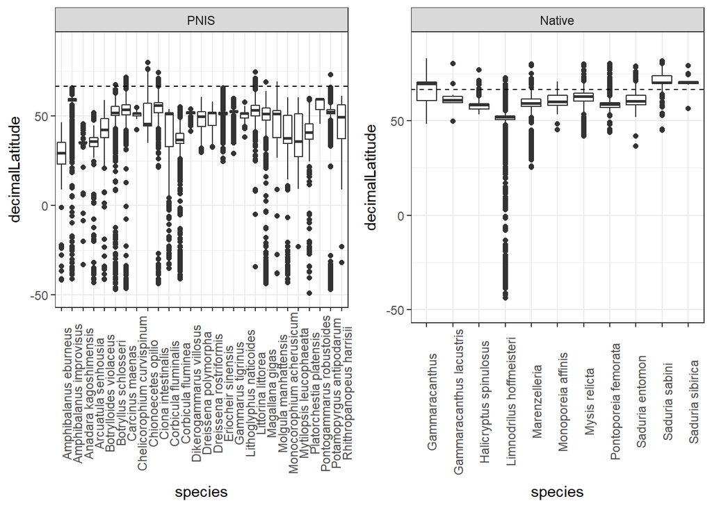

Пунктирная линия показывает Северный полярный круг.

Видно, что ареал почти у всех нативных видов имеет более северный характер. Хотя некоторые PNIS потенциально могут встречаться и в заполярье.

Каждый вид был охарактеризован несколькими переменными:

*Median_lat* - медиана значений широты. Предполагается, что эта величина характеризует широтное “ядро” нативного ареала.

*Upper_lat* - Максимальное значение широты, на которой встретился вид

*Q_low* - значение 2.5% квантиля широты

*Q_up* - значение 97.5% квантиля широты

*Prop_polar* - отношение количества точек с широтой выше Севарного полярного круга к общему количеству встреч. Предполагается, что чем выше это значение тем с большей вероятностью данный вид встречается в Заполярье.

*N_S_skewness* - величина асимметрии распределения значений широт. Предполагается, что чем асимметричнее распределение тем более выражена тенденция в смещении вида из нативного ареала.

$$asymmetry = \ln(\frac{|Q_{up} - M|}{|Q_{low}-M|})$$

Все эти характеристики были использованы в компонентном анализе, на основании которого была построена ординация видов.

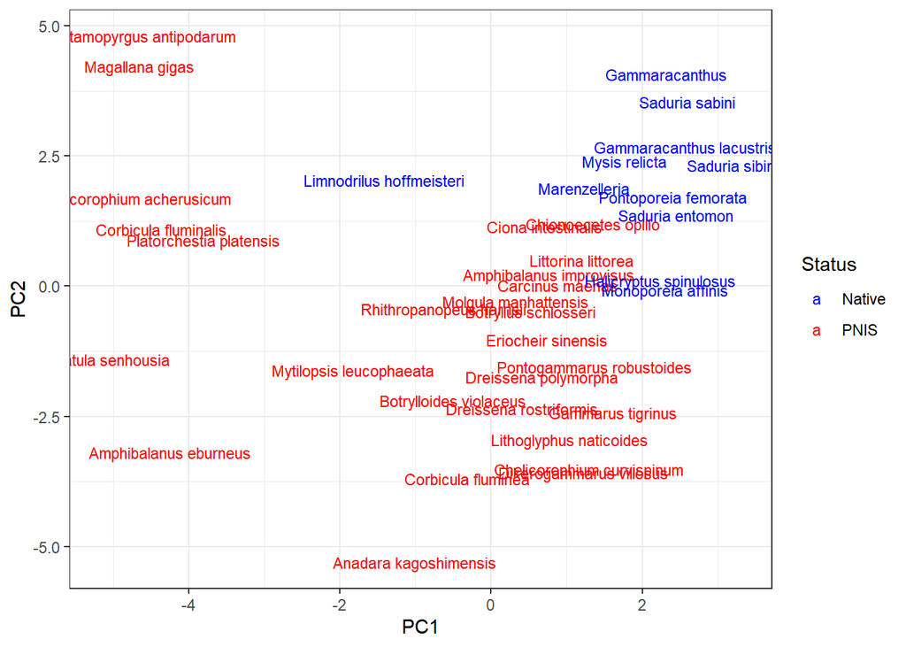

Видно, что нативные виды обладают достаточно сходными биогеографическими характеристиками. Исключение составляет Limnodrillus hoffmeisteri. Либо это ошибка в определнии, либо это космополит.

По своим биогеографическим параметрам в число близких к нативным видам попадают следующие PNIS: Amphibalanus improvisus, Botryllus schlosseri, Carcinus maenas, Chionoecetes opilio, Ciona intestinalis, Littorina littorea, Molgula manhattensis, Rhithropanopeus harrisii.

Из этих видов явно надо исключать Chionoecetes opilio и Botryllus schlosseri, как виды чисто морские. Остальные же вполне могут заселиться.

Важно отметить, что это картинка получена лишь на основе биогеографических данных. Если дастся добавить сюда еще оценку соленостной и температурной толерантности видов, то она может существенно измениться.